# What’s So Funny?

Brian Clare

December 18, 2017

## Gathering Data - Transcripts

The first thing we need to do is gather a bunch of data. .txt files of the transcripts and touring information that I’ve gathered is all included on my github so if you’re reading this you should have all of that Let’s get a couple functions to clean up that data, starting with transcripts

```r
data(stop_words)

read_transcript <- function(file, comedian, title){
  df <- read_table(file, col_names = FALSE)

  df <- df %>% unnest_tokens(word, X1) %>% filter(word != 'laughter')%>% filter(word != "audience") %>%
    filter(word != 'applause') %>% filter(word != 'music') %>% filter(word != "ll") %>%
    filter(word != "nt") %>% filter(word != "ve") %>% filter(word != "laughs") %>%  anti_join(stop_words) %>%
    count(word, sort = TRUE) %>% mutate(comedian = comedian, title = title) %>%
    mutate(RF = n / sum(n))

  return(df)
}
```

So this function will read in a file, split it into individual words, filter out words that are useless or commonly non-verbal, filter out stop words, then summarize for the total number of times each word is included in that file.

Here’s an example of how this function is used; I don’t want this document to be 100 pages long so I won’t show all of them here, but they’re in the “import transcripts.R” script which is included in github. There will be a lot of commented-out lines within the chunks of this Rmd file for that reason.

```r
#Amy Schumer
AS_Leather <- read_transcript("youtube//amy schumer the leather special.txt",
                              "Amy Schumer", "The Leather Special")
AS_Sex <- read_transcript("scraps//amy schumer mostly sex stuff.txt",
                          "Amy Schumer", "Mostly Sex Stuff")
AS_Live <- read_transcript("scraps//amy schumer live at the apollo.txt",
                           "Amy Schumer", "Live at the Apollo")
Amy_Schumer <- rbind(AS_Leather, AS_Sex, AS_Live) %>% group_by(word) %>%
  summarize(n = sum(n), name = max(comedian)) %>% arrange(desc(n)) %>% mutate(rf = n / sum(n))
```

After importing all the transcripts and combining each individual comedian’s pieces, we should look at all of the words

```r
all_words <- rbind(Amy_Schumer
      #              Aziz_Ansari, Ali_Wong, Bill_Burr, Bill_Hicks, Bo_Burnham, Brian_Posehn,
      # Chris_Rock, Dave_Chappelle, Demetri_Martin, Donald_Glover, Daniel_Tosh, Eddie_Murphy, Frankie_Boyle,
      # George_Carlin, Iliza_Sch, Jeff_Foxworthy, Jimmy_Carr, Jim_Gaffigan, Jim_Jefferies,
      # John_Mulaney, Louis_CK, Lenny_Bruce, Maria_Bamford, Neal_Brennan, Patton_Oswalt, Richard_Pryor,
      # Ron_White, Ricky_Gervais, Steve_Harvey, Tom_Segura, Steven_Wright, Redd_Foxx, Jerry_Seinfeld,
      # Hannibal_Burress
      ) %>% group_by(word) %>%
  summarize(n = sum(n))%>% arrange(desc(n)) %>% mutate(rf = n / sum(n))

words_only <- all_words %>% select(word)

text_norm <- function(comedian){
  normalized <- right_join(comedian, words_only)%>%
    mutate(n = ifelse(is.na(n), 0, n), rf = n / sum(n))
  return(normalized)
}

AS_norm <- text_norm(Amy_Schumer)
```

This chunk will make a list of all words used by these comedians, and then “normalizes” each comedian’s vocabulary by showing the relative frequencies of every word for that comedian.

Now let’s get everyone’s frequencies of every word into one big big big table. We’ll need this later.

```r
comedians_list <- c("Amy Schumer", "Aziz Ansari", "Ali Wong", "Bill Burr", "Bill Hicks",
  "Bo Burnham", "Brian Posehn", "Chris Rock", "Dave Chappelle", "Demetri Martin",
  "Donald Glover", "Daniel Tosh", "Eddie Murphy", "Frankie Boyle", "George Carlin",
  "Iliza Shlesinger", "Jeff Foxworthy", "Jimmy Carr", "Jim Gaffigan", "Jim Jefferies",
  "John Mulaney", "Louis CK", "Lenny Bruce", "Maria Bamford", "Neal Brennan", "Patton Oswalt",
  "Richard Pryor", "Ron White", "Ricky Gervais", "Steve Harvey", "Tom Segura", "Steven Wright",
  "Redd Foxx", "Jerry Seinfeld", "Hannibal Burress", "Larry the Cable Guy", "Mitch Hedberg",
  "Bill Engvall")

master <- rbind(Amy_Schumer
                # Aziz_Ansari, Ali_Wong, Bill_Burr, Bill_Hicks, Bill_Engvall,
                # Bo_Burnham, Chris_Rock, Brian_Posehn, Dave_Chappelle, Demetri_Martin,
                # Donald_Glover, Daniel_Tosh, Eddie_Murphy, Frankie_Boyle, George_Carlin,
                # Iliza_Sch, Jeff_Foxworthy, Jimmy_Carr, Jim_Gaffigan, Jim_Jefferies,
                # John_Mulaney, Louis_CK, Lenny_Bruce, Maria_Bamford, Neal_Brennan,
                # Patton_Oswalt, Richard_Pryor, Ron_White, Ricky_Gervais, Steve_Harvey,
                # Steven_Wright, Redd_Foxx, Jerry_Seinfeld, Hannibal_Burress, Larry_Cableguy,
                # Mitch_Hedberg, Tom_Segura
                )

master_freq <- AS_norm$n
# AA_norm$n + AW_norm$n + Burr_norm$n + BH_norm$n + BE_norm$n + BB_norm$n +
#         CR_norm$n + BP_norm$n + DC_norm$n + DM_norm$n + DG_norm$n + DT_norm$n + EM_norm$n + FB_norm$n +
#         GC_norm$n + IS_norm$n + JF_norm$n + JC_norm$n + JG_norm$n + JJ_norm$n + JM_norm$n + CK_norm$n +
#         LB_norm$n + MB_norm$n + NB_norm$n + PO_norm$n + RP_norm$n + RW_norm$n + RG_norm$n + SH_norm$n +
#         SW_norm$n + RF_norm$n + JS_norm$n + HB_norm$n + LC_norm$n + MH_norm$n + TS_norm$n

master_freq <- cbind(words_only, master_freq)
colnames(master_freq) <- c("Word", "Frequency")
```

Finally we’ll make some lists of the most used words, so that we can check back with them later

```r
top500 <- master_freq %>% top_n(500, Frequency) %>% arrange(desc(Frequency))
top500_words <- as.tibble(top500$Word)
colnames(top500_words) <- c("word")


top10 <- master_freq %>% top_n(10, Frequency) %>% arrange(desc(Frequency))
top10_words <- as.tibble(top10$Word)
colnames(top10_words) <- c("word")

top500rf <- top500 %>%  mutate(rf = Frequency / sum(Frequency))
```

## Gathering Data - Touring

Okay, similar idea here. We’ll start with a couple functions to read in and clean the .txt files

```r
read_tour <- function(file, comedian){
  doc <- read_tsv(file, col_names = TRUE) %>% unique() %>% select(-Ignore) %>%
    mutate(name = comedian) %>%
    separate(col = Location, into = c("City", "State"), sep = ", ")
  return(doc)
}

#The site where I found this data only listed the year if it wasn't this year (2017), so I had to add those in for recent shows

fix_dates <- function(table){
  for(i in 1:length(table$Date)){
    if(!grepl(",", table$Date[i], fixed = TRUE)){
      table$Date[i] <- str_c(table$Date[i], ", 2017", sep = "")
    }
  }

  table <- table %>% separate(col = Date, into = c("MD", "Year"), sep = ",")
  table <- table %>% separate(col = MD, into = c("Month", "Day"), sep = " ")
  return(table)
}
```

One of the things I’m curious about is how often these comedians do shows outside the US; most are Americans but a few are not, and I bet they have a lower % of their shows in the US

Most of the shows are in the US though, so let’s filter down to those and group by state

```r
#Who is in the US the most?
US_ratio <- function(tour, US){
  ratio <- length(US$Venue) / length(tour$Venue)
  return(ratio)
}

data(state)
state_list <- as.tibble(matrix(state.abb), bycol = FALSE)
colnames(state_list) <- c("State")

by_state <- function(comedian){
  df <- comedian %>% group_by(State) %>% summarize(count = n()) %>% right_join(state_list) %>%
    mutate(rel_freq = count / sum(count, na.rm = TRUE))
  return(df)
}
```

We don’t have tour data for everyone that had transcript data. Some of those comedians are older, several are dead, and a few I just couldn’t find. Here’s who we have, and then Amy Schumer again as an example of pulling in the data

```r
tour_names <- c("Amy Schumer", "Aziz Ansari", "Bill Burr", "Bill Engvall", "Bo Burnham",
                "Brian Posehn","Chris Rock", "Daniel Tosh", "Dave Chappelle", "Demetri Martin",                         "Frankie Boyle", "Hannibal Burress","Iliza Schlesinger", "Jeff Foxworthy",
                "Jim Gaffigan", "Jim Jefferies", "Jimmy Carr", "John Mulaney", "Louis CK",
                "Neal Brennan", "Patton Oswalt", "Ron White", "Tom Segura", "Larry the Cable Guy",
                "Maria Bamford")

Ratios <- as.tibble(matrix(c(0), nrow = length(tour_names), ncol = 3))
colnames(Ratios) <- c("Comedian", "Ratio of US Shows", "Number of Shows")
Ratios$Comedian <- tour_names

#Amy Schumer
schumer_tour <- read_tour("shows//amy schumer.txt", "Amy Schumer")
schumer_tour <- fix_dates(schumer_tour)
schumer_US <- schumer_tour %>% filter(State %in% state.abb)
Ratios$`Ratio of US Shows`[1] <- US_ratio(schumer_tour, schumer_US)
Ratios$`Number of Shows`[1] <- length(schumer_tour$Venue)
```

Now that we have lists of how many times each comedian has played in each state, let’s summarize and get things into tidy format for future use

```r
state_freqs <- as.tibble(t(cbind(by_state(schumer_US)$count
                                 # by_state(ansari_US)$count,
                                 # by_state(burr_US)$count, by_state(engvall_US)$count,
                                 # by_state(burnham_US)$count, by_state(posehn_US)$count,
                                 # by_state(rock_US)$count, by_state(tosh_US)$count,
                                 # by_state(chappelle_US)$count, by_state(martin_US)$count,
                                 # by_state(boyle_US)$count, by_state(burress_US)$count,
                                 # by_state(iliza_US)$count, by_state(fw_US)$count,
                                 # by_state(gaffigan_US)$count, by_state(jefferies_US)$count,
                                 # by_state(carr_US)$count, by_state(mulaney_US)$count,
                                 # by_state(ck_US)$count, by_state(brennan_US)$count,
                                 # by_state(oswalt_US)$count, by_state(white_US)$count,
                                 # by_state(segura_US)$count, by_state(larry_US)$count,
                                 # by_state(bamford_US)$count
                                 )) )
state_freqs[is.na(state_freqs)] <- 0
colnames(state_freqs) <- state.name

state_freqs <- as.tibble(cbind(tour_names, state_freqs))
colnames(state_freqs)[1] <- "Comedian"

combined_state_freqs <- as.tibble(colSums(state_freqs[2:51]))
combined_state_freqs <- as.tibble(cbind(tolower(state.name), combined_state_freqs$value))
colnames(combined_state_freqs) <- c("region", "Total")

state_rel_freqs <- as.tibble(t(cbind(by_state(schumer_US)$rel_freq
                                     # by_state(ansari_US)$rel_freq,
                                     # by_state(burr_US)$rel_freq, by_state(engvall_US)$rel_freq,
                                     # by_state(burnham_US)$rel_freq, by_state(posehn_US)$rel_freq,
                                     # by_state(rock_US)$rel_freq, by_state(tosh_US)$rel_freq,
                                     # by_state(chappelle_US)$rel_freq, by_state(martin_US)$rel_freq,
                                     # by_state(boyle_US)$rel_freq, by_state(burress_US)$rel_freq,
                                     # by_state(iliza_US)$rel_freq, by_state(fw_US)$rel_freq,
                                     # by_state(gaffigan_US)$rel_freq, by_state(jefferies_US)$rel_freq,
                                     # by_state(carr_US)$rel_freq, by_state(mulaney_US)$rel_freq,
                                     # by_state(ck_US)$rel_freq, by_state(brennan_US)$rel_freq,
                                     # by_state(oswalt_US)$rel_freq, by_state(white_US)$rel_freq,
                                     # by_state(segura_US)$rel_freq, by_state(larry_US)$rel_freq,
                                     # by_state(bamford_US)$rel_freq
                                     )) )
state_rel_freqs[is.na(state_rel_freqs)] <- 0
colnames(state_rel_freqs) <- state.name

state_rel_freqs <- as.tibble(cbind(tour_names, state_rel_freqs))
colnames(state_rel_freqs)[1] <- "Comedian"

state_for_map <- as.tibble(t(select(state_rel_freqs, -Comedian)))
colnames(state_for_map) <- tour_names
state_for_map$region <- state.name
```

## Finally some analysis - TF-IDF

So what we’ll do now is find the tf-idf for each word used by each comedian, from the “master” table we made earlier. tf is term frequency (how often the comedian uses that word) and idf is inverse document frequency; a document here is one comedian, so basically how many other comedians use that word. A larger value for tf-idf means that word is more distinctive for that comedian.

```r
idf <- master %>% bind_tf_idf(word, name, n)
```

```r
word_matrix <- as.tibble(rbind(t(left_join(as.tibble(top500_words), AS_norm) %>% select(rf))
                               # etc etc for every other comedian
                               # It was tricky getting this code to work right and there's
                               # probably a nicer-looking way to do it
))
colnames(word_matrix) <- t(top500_words)

word_matrix <- cbind(comedians_list, word_matrix)

colnames(word_matrix)[1] <- "Name"
```

When we have this table, we can use it to find distances between comedians by vocabulary, and with distances we can find clusters by similarity of word use

```r
# clusters <- kmeans(word_matrix[2:501], 10, nstart = 20)
# word_matrix$cluster <- as.factor(clusters$cluster)
#
# comedy_clusters <- word_matrix %>% select(Name, cluster)
```

There’s a bit more code in the tfidf.R script about looking at the top words for each cluster, and zooming in to the largest cluster. The conclusions are laid out in the google slides presentation.

## Rankings

In an effort to quantify the idea of the best or funniest standup comedians, I came across a few different rankings. While there were some interesting rankings of the best standup specials, most influential comedians, and others, I stuck with 3 rankings of the greatest comedians of all time. I entered the results into an excel file, then read it into R

```r
ranks <- read_xlsx("rankings.xlsx")
ranks <- ranks %>% mutate(Avg = rowMeans(ranks[2:4], na.rm = TRUE))

ranks$adjustment <- rowSums(is.na(ranks))
ranks$adj_avg <- ranks$Avg / ( 1- (ranks$adjustment / 3))
```

## Swearing

One of the central dividers in standup comedy is between comics who curse regularly and those who don’t. I’ve defined what I subjectively feel are the strongest swear words, and looked at how often those words are used by comedians.

```r
swears <- c("fuck", "fucking", "shit", "fucked", "motherfuckers", "cunt")
swear_matrix <- word_matrix %>% select(Name, swears)
swear_matrix <- swear_matrix %>% mutate(total_freq = rowSums(swear_matrix[2:7])) %>%
  select(Comedian = Name, total_freq)
```

## Models

Okay so does swearing make you funnier? Well not you personally, but successful standup comedians. We’ll build a simple linear model here to examine the relationship, and then plot a graph.

```r
ranks_min <- ranks %>% select(Comedian, Ranking = adj_avg) %>% filter(Ranking < 50)

model_swears <- inner_join(ranks_min, swear_matrix)
model_swears <- model_swears %>% select(Comedian, Swears = total_freq, Ranking) %>%
  mutate(Swears = 100*Swears)

model_swears$decade <- c("70s", "70s", "90s", "00s", "00s", "80s", "80s", "10s", "60s", "90s",
                         "00s", "60s", "90s", "00s", "00s", "10s")

lm_swears <- lm(data = model_swears, Ranking ~ Swears)
summary(lm_swears)
```

```
##
## Call:
## lm(formula = Ranking ~ Swears, data = model_swears)
##
## Residuals:
##     Min      1Q  Median      3Q     Max
## -15.771  -9.771  -1.604   4.562  24.562
##
## Coefficients: (1 not defined because of singularities)
##             Estimate Std. Error t value Pr(>|t|)
## (Intercept)   17.438      3.065    5.69 4.29e-05 ***
## Swears            NA         NA      NA       NA
## ---
## Signif. codes:  0 '***' 0.001 '**' 0.01 '*' 0.05 '.' 0.1 ' ' 1
##
## Residual standard error: 12.26 on 15 degrees of freedom
```

```r
factor(model_swears$decade, levels = c("60s", "70s", "80s", "90s", "00s", "10s"))
```

```
##  [1] 70s 70s 90s 00s 00s 80s 80s 10s 60s 90s 00s 60s 90s 00s 00s 10s
## Levels: 60s 70s 80s 90s 00s 10s
```

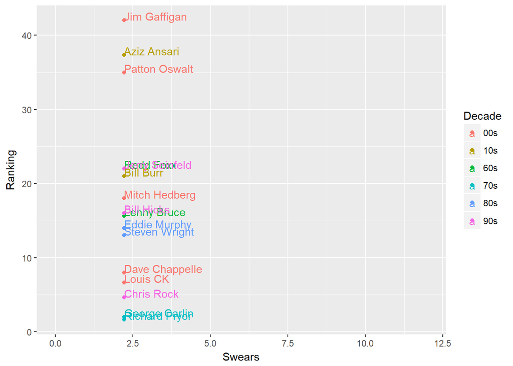

```r
ggplot(data = model_swears, mapping = aes(x = Swears, y = Ranking, label = Comedian, color = decade)) +
  geom_point() + geom_text(aes(label = Comedian), hjust = 0, vjust = 0) +
  scale_x_continuous(limits = c(0, 12)) + scale_color_discrete(name = "Decade")
```

This turns out to be a less fruitful endeavor, but I also wanted to look at the effect of various words on ranking. I didn’t want to spend the time doing a regression for every single word, but because of the small sample size I couldn’t reasonably use a large number of words, so I’ve just looked at the top 10 words in overall frequency.

```r
top10_word_matrix <- word_matrix %>% select(Comedian = Name, top10_words$word)

model_words <- inner_join(ranks_min, top10_word_matrix)
model_words <- model_words %>% select(-Comedian)

lm_words <- lm(data = model_words, Ranking ~ .)
summary(lm_words)
```

```
##
## Call:
## lm(formula = Ranking ~ ., data = model_words)
##
## Residuals:
##     Min      1Q  Median      3Q     Max
## -15.771  -9.771  -1.604   4.562  24.562
##
## Coefficients: (11 not defined because of singularities)
##             Estimate Std. Error t value Pr(>|t|)
## (Intercept)   17.438      3.065    5.69 4.29e-05 ***
## don               NA         NA      NA       NA
## guys              NA         NA      NA       NA
## um                NA         NA      NA       NA
## guy               NA         NA      NA       NA
## uh                NA         NA      NA       NA
## gonna             NA         NA      NA       NA
## fuck              NA         NA      NA       NA
## girl              NA         NA      NA       NA
## people            NA         NA      NA       NA
## love              NA         NA      NA       NA
## yeah              NA         NA      NA       NA
## ---
## Signif. codes:  0 '***' 0.001 '**' 0.01 '*' 0.05 '.' 0.1 ' ' 1
##
## Residual standard error: 12.26 on 15 degrees of freedom
```

## Mapping

We have all that tour data but we haven’t really used it yet. Let’s try to make some pretty maps of the US showing where comedians go. This next chunk mostly just sets up a few things

```r
all_states <- map_data("state")
state_for_map$region <- sapply(state_for_map$region, tolower)
tours_by_state <- full_join(state_for_map, all_states)
tours_by_state$region <- as.factor(tours_by_state$region)
tours_by_state <- tours_by_state %>% filter(is.na(long) == FALSE)

tours_by_state[is.na(tours_by_state)] <- 0


ditch_the_axes <- theme(
  axis.text = element_blank(),
  axis.line = element_blank(),
  axis.ticks = element_blank(),
  panel.border = element_blank(),
  panel.grid = element_blank(),
  axis.title = element_blank(),
  legend.title = element_blank()
)

combined_state_map <- full_join(combined_state_freqs, all_states)
combined_state_map$region <- as.factor(combined_state_map$region)
combined_state_map$Total <- as.numeric(combined_state_map$Total)

mid <- mean(combined_state_map$Total, na.rm = TRUE)
lmid <- log(mid)
```

Okay great - let’s make the plots. Here’s all comedians combined, then an example for just one comedian

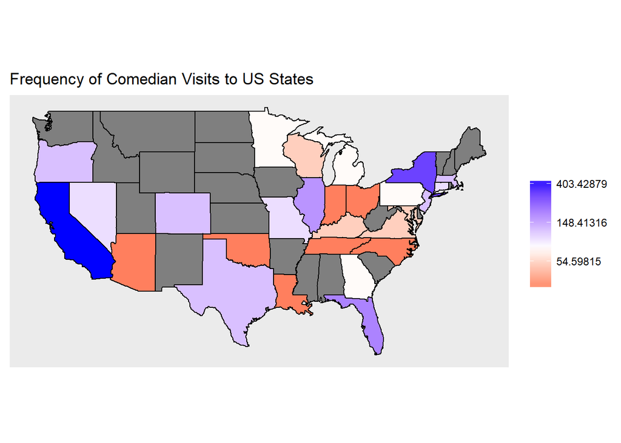

```r
ggplot(data = combined_state_map) + geom_polygon(aes(x = long, y = lat, group = group, fill = Total),
                                                 color = "black") +
  scale_fill_gradient2(midpoint = lmid, low = "red", high = "blue", mid = "white",
                       space = "Lab", trans = "log") + coord_fixed(1.3) + ditch_the_axes +
  labs(title = "Frequency of Comedian Visits to US States")
```

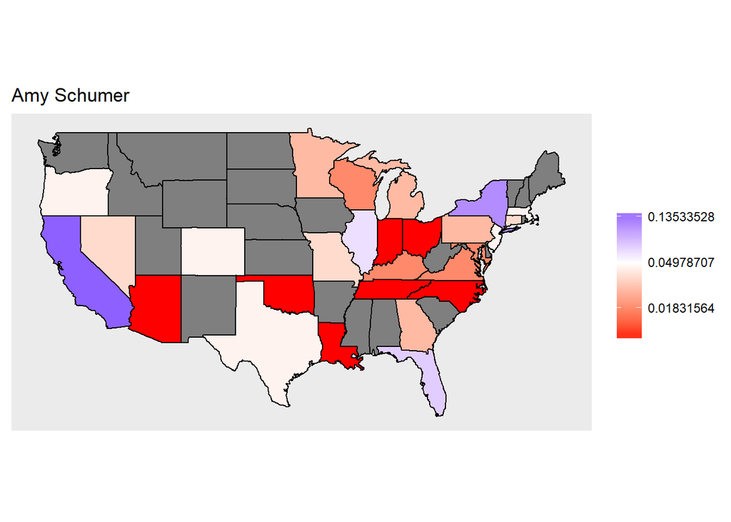

```r
ggplot() + geom_polygon(data = tours_by_state,
                        mapping = aes(x = long, y = lat, group = group, fill = `Amy Schumer`),
                        color = "black") +
  coord_fixed(1.3) + ditch_the_axes +
  scale_fill_gradient2(midpoint = log(0.05), low = "red", high = "blue", mid = "white",
                       space = "Lab", trans = "log") +
  labs(title = "Amy Schumer")
```